# Anteproyecto - Filtro

Erik Mejia Hernandez - Adrian Homero Moreno Garcia - Julieta Guadalupe Ruiz Rodriguez

16 de marzo de 2017

### —————————–

### UAZ Students

###### This dataset contains relevant data of the students who are studying the undergraduate level of different programs at the Autonomous University of Zacatecas.

###### The data were obtained through surveys that were made to the student population, later we selected those that could help us in our investigation.

###### The data set file’s name is datasetUAZ.csv, in the next block we read the dataset to continue working with it.

```r
knitr::opts_chunk$set(echo = TRUE)

dsuaz <- read.csv("datasetUAZ.csv", stringsAsFactors = FALSE)
```

#### The Survey

###### The main limitation we found when trying to conduct the survey was the time we had and the amount of answers we were supposed to have, for that reason we decided to do it digitally with the help of social networks.

###### Due to this we had the disadvantage that the students answered very attached to their feelings and not in an objective way, due to this our data needed of format and cleaning that we had to realize by hand.

###### Then we can observe each one of the questions we made and some examples of the types of answers that we obtained:

```r
str(dsuaz)
```

```
## 'data.frame':    113 obs. of  24 variables:
##  $ hrs_estudio_dia        : int  4 4 0 4 4 4 4 4 0 6 ...
##  $ hrs_tv_dia             : int  0 2 0 0 4 0 0 0 2 4 ...
##  $ hrs_vjuegos_dia        : int  4 0 0 0 4 0 0 0 2 0 ...
##  $ hrs_actsocial_dia      : int  2 1 2 1 0 3 0 1 1 0 ...
##  $ hrs_universidad_dia    : int  7 8 4 7 7 6 7 6 8 7 ...
##  $ promedio               : num  8 8.7 9.6 8.2 8.5 9.3 8 7.6 7.2 7 ...
##  $ hrs_ejercicio_dia      : int  0 0 4 0 4 0 0 0 4 0 ...
##  $ hrs_dormir_dia         : int  8 6 8 6 8 8 8 8 6 6 ...
##  $ transporte_publico     : int  1 1 0 1 1 1 1 1 0 1 ...
##  $ comedor                : int  1 1 0 1 0 1 0 0 0 1 ...
##  $ becario                : int  1 1 1 1 0 1 0 0 0 0 ...
##  $ materias_repetidas     : int  0 0 0 0 1 0 1 5 2 0 ...
##  $ dificultad_licenciatura: int  3 2 2 4 3 2 4 3 2 4 ...
##  $ pasion_licenciatura    : int  8 9 8 9 9 10 10 7 6 7 ...
##  $ oferta_laboral         : int  5 8 9 10 9 4 10 9 8 5 ...
##  $ Ssalario_estimado      : chr  "10 - 15 mil" "15 - 20 mil" "mas de 20 mil" "6 - 10 mil" ...
##  $ hrs_trabajo            : int  10 10 10 12 8 8 12 8 12 10 ...
##  $ municipio              : chr  "Morelos" "Ojocaliente" "Orizaba" "Naucalpan" ...
##  $ genero                 : chr  "Hombre" "Hombre" "Hombre" "Mujer" ...
##  $ edad                   : int  18 20 21 19 20 22 19 25 22 18 ...
##  $ licenciatura           : chr  "Ingenieria de Software" "Quimico Farmaceutico Biologo" "Ingenieria de Software" "Medicina Humana" ...
##  $ semestre               : int  2 1 8 2 4 10 2 8 8 2 ...
##  $ planes_egreso          : chr  "Posgrado" "Laborar" "Posgrado" "Posgrado" ...
##  $ X                      : logi  NA NA NA NA NA NA ...
```

##### Head & Tail

###### With the head and tail functions we can get a small sample of the data, those first six records with each of its attributes and their values and the last six records of the dataset.

```r
head(dsuaz)
```

```
##   hrs_estudio_dia hrs_tv_dia hrs_vjuegos_dia hrs_actsocial_dia
## 1               4          0               4                 2
## 2               4          2               0                 1
## 3               0          0               0                 2
## 4               4          0               0                 1
## 5               4          4               4                 0
## 6               4          0               0                 3
##   hrs_universidad_dia promedio hrs_ejercicio_dia hrs_dormir_dia
## 1                   7      8.0                 0              8
## 2                   8      8.7                 0              6
## 3                   4      9.6                 4              8
## 4                   7      8.2                 0              6
## 5                   7      8.5                 4              8
## 6                   6      9.3                 0              8
##   transporte_publico comedor becario materias_repetidas
```

[output cut: 27 more lines]

```r
tail(dsuaz)
```

```
##     hrs_estudio_dia hrs_tv_dia hrs_vjuegos_dia hrs_actsocial_dia
## 108               4          4               0                 1
## 109               4          4               4                 3
## 110               4          4               0                 2
## 111               4          0               0                 3
## 112               4          4               0                 2
## 113               4          2               0                 2
##     hrs_universidad_dia promedio hrs_ejercicio_dia hrs_dormir_dia
## 108                   7     9.30                 0              8
## 109                   4     8.30                 0              8
## 110                   6     8.00                 4              8
## 111                   6     8.57                 4              8
## 112                   6     9.50                 0              8
## 113                   6     8.70                 2              6
##     transporte_publico comedor becario materias_repetidas
```

[output cut: 27 more lines]

##### Dataset Summary

###### With the summary function we obtain different statistics of the data stored in the dataset. This function invokes different methods according to the type of object that is. Receiving as argument, in this specific case is a dataset.

###### We can observe the values: minimum, maximum, mean, median and quartiles of each of the variables that make up the dataset.

```r
summary(dsuaz)
```

```
##  hrs_estudio_dia   hrs_tv_dia    hrs_vjuegos_dia hrs_actsocial_dia
##  Min.   :0.000   Min.   :0.000   Min.   :0.000   Min.   : 0.000
##  1st Qu.:4.000   1st Qu.:0.000   1st Qu.:0.000   1st Qu.: 1.000
##  Median :4.000   Median :0.000   Median :0.000   Median : 2.000
##  Mean   :4.248   Mean   :1.593   Mean   :1.168   Mean   : 2.248
##  3rd Qu.:4.000   3rd Qu.:4.000   3rd Qu.:4.000   3rd Qu.: 3.000
##  Max.   :8.000   Max.   :6.000   Max.   :6.000   Max.   :10.000
##  hrs_universidad_dia    promedio     hrs_ejercicio_dia hrs_dormir_dia
##  Min.   :0.000       Min.   :7.000   Min.   :0.000     Min.   : 3.000
##  1st Qu.:6.000       1st Qu.:8.000   1st Qu.:0.000     1st Qu.: 6.000
##  Median :7.000       Median :8.400   Median :0.000     Median : 8.000
##  Mean   :6.301       Mean   :8.423   Mean   :1.327     Mean   : 6.973
##  3rd Qu.:7.000       3rd Qu.:8.980   3rd Qu.:4.000     3rd Qu.: 8.000
##  Max.   :8.000       Max.   :9.800   Max.   :4.000     Max.   :10.000
##  transporte_publico    comedor          becario       materias_repetidas
##  Min.   :0.0000     Min.   :0.0000   Min.   :0.0000   Min.   :0.0000
##  1st Qu.:1.0000     1st Qu.:0.0000   1st Qu.:0.0000   1st Qu.:0.0000
##  Median :1.0000     Median :0.0000   Median :0.0000   Median :0.0000
##  Mean   :0.8053     Mean   :0.4956   Mean   :0.3186   Mean   :0.4071
##  3rd Qu.:1.0000     3rd Qu.:1.0000   3rd Qu.:1.0000   3rd Qu.:0.0000
##  Max.   :1.0000     Max.   :1.0000   Max.   :1.0000   Max.   :5.0000
##  dificultad_licenciatura pasion_licenciatura oferta_laboral
##  Min.   :1.000           Min.   : 4.000      Min.   : 0.000
##  1st Qu.:2.000           1st Qu.: 8.000      1st Qu.: 5.000
##  Median :2.000           Median : 9.000      Median : 8.000
##  Mean   :2.549           Mean   : 8.735      Mean   : 7.097
##  3rd Qu.:3.000           3rd Qu.:10.000      3rd Qu.: 9.000
##  Max.   :4.000           Max.   :10.000      Max.   :10.000
##  Ssalario_estimado   hrs_trabajo      municipio            genero
##  Length:113         Min.   : 8.000   Length:113         Length:113
##  Class :character   1st Qu.: 8.000   Class :character   Class :character
##  Mode  :character   Median :10.000   Mode  :character   Mode  :character
##                     Mean   : 9.637
##                     3rd Qu.:10.000
##                     Max.   :13.000
##       edad       licenciatura          semestre      planes_egreso
##  Min.   :18.00   Length:113         Min.   : 1.000   Length:113
##  1st Qu.:19.00   Class :character   1st Qu.: 2.000   Class :character
##  Median :21.00   Mode  :character   Median : 6.000   Mode  :character
##  Mean   :20.99                      Mean   : 6.044
##  3rd Qu.:22.00                      3rd Qu.: 8.000
##  Max.   :28.00                      Max.   :10.000
##     X
##  Mode:logical
##  NA's:113
##
##
##
##
```

#### Variables Description

##### Gender

###### The interview was conducted to students of the UAZ, of which 51 were men and 62 women.

```r
table(dsuaz$genero)
```

```
##
## Hombre  Mujer
##     51     62
```

##### Age

###### The ages of the students interviewed range from 18 to 28 years. In the next block we can observe the number of students interviewed for each of the ages obtained with the survey.

###### But we can also observe other data with the summary function, note that the first quartile is in 19 years and the third in 22 years, which indicates that the greater number of students is between these ages, in fact the Median is 21 years, if we go back a little, we can see that actually 21 years has the largest number of students same that 22 years.

```r
table(dsuaz$edad)
```

```
##
## 18 19 20 21 22 23 24 25 26 28
## 13 19 11 23 23 15  6  1  1  1
```

```r
summary(dsuaz$edad)
```

```
##    Min. 1st Qu.  Median    Mean 3rd Qu.    Max.
##   18.00   19.00   21.00   20.99   22.00   28.00
```

##### Town

###### In the next block we can see from which city the students interviewed come from.

```r
table(dsuaz$municipio)
```

```
##
##              Calera  Concepcion del Oro           Fresnillo
##                   9                   2                   7
##           Guadalupe Huejuquilla el Alto               Jerez
##                  11                   2                  19
##             Mazapil             Morelos           Naucalpan
##                   1                   2                   2
##         Ojocaliente             Orizaba      Panfilo natera
##                   2                   1                   1
##              Panuco               Pinos          Rio Grande
##                   5                   2                   2
##     San Luis Potosi          Sombrerete          Susticacan
##                   1                   2                   1
##             Tabasco           Tepetongo      Tlaltenago Zac
##                   2                   3                   2
##             Torreon          Valparaiso           Zacatecas
##                   1                   1                  32
```

##### Study Hours per day

###### We asked the interviewed students how many hours they spend studying outside the university, most spend between 4 and 6 hours studying a day.

```r
table(dsuaz$hrs_estudio_dia)
```

```
##
##  0  4  6  8
##  8 81 18  6
```

```r
summary(dsuaz$hrs_estudio_dia)
```

```
##    Min. 1st Qu.  Median    Mean 3rd Qu.    Max.
##   0.000   4.000   4.000   4.248   4.000   8.000
```

##### Tv hours per day

###### More than half of the total number of students interviewed responded by not spending any time watching TV per day. However we still have 39 students watch 4 hours of TV per day and a student who watches TV 6 hours per day.

```r
table(dsuaz$hrs_tv_dia)
```

```
##
##  0  2  4  6
## 64  9 39  1
```

```r
summary(dsuaz$hrs_tv_dia)
```

```
##    Min. 1st Qu.  Median    Mean 3rd Qu.    Max.
##   0.000   0.000   0.000   1.593   4.000   6.000
```

##### Exercise hours per day

###### Most students do not do any type of exercise a day, only 39 students are those who perform 2 to 4 hours of exercise per day.

```r
table(dsuaz$hrs_ejercicio_dia)
```

```
##
##  0  2  4
## 74  3 36
```

```r
summary(dsuaz$hrs_ejercicio_dia)
```

```
##    Min. 1st Qu.  Median    Mean 3rd Qu.    Max.
##   0.000   0.000   0.000   1.327   4.000   4.000
```

##### Hours of social activity per day

###### Almost all students interviewed said they have time for social activities per day, most students spend between 1 and 3 hours a day to interact with other people.

```r
table(dsuaz$hrs_actsocial_dia)
```

```
##
##  0  1  2  3  4  5  6  8  9 10
## 16 25 30 24  9  2  4  1  1  1
```

```r
summary(dsuaz$hrs_actsocial_dia)
```

```
##    Min. 1st Qu.  Median    Mean 3rd Qu.    Max.
##   0.000   1.000   2.000   2.248   3.000  10.000
```

##### Hours students spend in college

###### Students spend from 0 to 8 hours in college. The median is 7, and the first and third quartiles are between 6 and 7, so that most of the students, 91 to be exact, spend from 6 to 7 hours receiving classes in classrooms.

```r
table(dsuaz$hrs_universidad_dia)
```

```
##
##  0  4  6  7  8
##  1 13 41 50  8
```

```r
summary(dsuaz$hrs_universidad_dia)
```

```
##    Min. 1st Qu.  Median    Mean 3rd Qu.    Max.
##   0.000   6.000   7.000   6.301   7.000   8.000
```

##### Hours of sleep per day

###### In the next block we can see that most students sleep between 6 and 8 hours a day, few students sleep less than 6 hours per day and are even fewer those who sleep more than 10 hours .

###### Given the number of hours recommended for anyone to sleep, we have obtained good answers from the students.

```r
table(dsuaz$hrs_dormir_dia)
```

```
##
##  3  6  8 10
##  8 42 59  4
```

```r
summary(dsuaz$hrs_dormir_dia)
```

```
##    Min. 1st Qu.  Median    Mean 3rd Qu.    Max.
##   3.000   6.000   8.000   6.973   8.000  10.000
```

##### Use of public transportation between students

###### We used the values 0 for answer no, and 1 for yes. So, most of the students use the public transportation, just 22 students dont use it.

```r
table(dsuaz$transporte_publico)
```

```
##
##  0  1
## 22 91
```

```r
summary(dsuaz$transporte_publico)
```

```
##    Min. 1st Qu.  Median    Mean 3rd Qu.    Max.
##  0.0000  1.0000  1.0000  0.8053  1.0000  1.0000
```

##### Use of cafeteria between students

###### We used the values 0 for answer no, and 1 for yes. In this case the results are pretty balanced, only 50 percent plus one, that is, 57 of the students do not use the college canteen and 56 of the students interviewed do so.

```r
table(dsuaz$comedor)
```

```
##
##  0  1
## 57 56
```

```r
summary(dsuaz$comedor)
```

```
##    Min. 1st Qu.  Median    Mean 3rd Qu.    Max.
##  0.0000  0.0000  0.0000  0.4956  1.0000  1.0000
```

##### Students who have a scholarship

###### We used the values 0 for answer no, and 1 for yes.

```r
table(dsuaz$becario)
```

```
##
##  0  1
## 77 36
```

```r
summary(dsuaz$becario)
```

```
##    Min. 1st Qu.  Median    Mean 3rd Qu.    Max.
##  0.0000  0.0000  0.0000  0.3186  1.0000  1.0000
```

##### Students per career

###### The interview was released to UAZ students, but as mentioned earlier we eliminated the answers from those who did not have enough results to study.

###### Therefore our study has been done with the students of the following four careers:

###### —> Software Engineering

###### —> Medicine

###### —> Psychology

###### —> Pharmaceutical Chemist Biologist

###### In the next block we can find the amount of students in each career.

```r
table(dsuaz$licenciatura)
```

```
##
##       Ingenieria de Software              Medicina Humana
##                           33                           30
##                   Psicologia Quimico Farmaceutico Biologo
##                           25                           25
```

##### Semester students

###### We interview students from each semester of the different careers, the semesters of which we have the most results are the second, eighth and tenth semester. The first and third quartiles tell us where the greatest number of students are, between the second and eighth semester.

```r
table(dsuaz$semestre)
```

```
##
##  1  2  3  4  5  6  7  8  9 10
##  4 28  1 11  4  9  1 27  1 27
```

```r
summary(dsuaz$semestre)
```

```
##    Min. 1st Qu.  Median    Mean 3rd Qu.    Max.
##   1.000   2.000   6.000   6.044   8.000  10.000
```

##### Difficulty perceived by students of their career

###### Students also asked about the difficulty with which they perceived their studies in each race, values are:

###### —> 1: Easy

###### —> 2: Regular

###### —> 3: Difficult

###### —> 4: Very Difficult

###### Looking at the results of the summary we realize that almost all students think that their career is regular or difficult, there were students who thought it was easy or very difficult, but one hundred students were the opinion among the first and third quartile, regular or difficult.

```r
table(dsuaz$dificultad_licenciatura)
```

```
##
##  1  2  3  4
##  3 55 45 10
```

```r
summary(dsuaz$dificultad_licenciatura)
```

```
##    Min. 1st Qu.  Median    Mean 3rd Qu.    Max.
##   1.000   2.000   2.000   2.549   3.000   4.000
```

##### Passion of students for their career

###### Another important part that we wanted to find out was the passion that every student has for his career, we gave them a scale of 1 to 10, in which 1 was nothing at all to 10, very passionate.

###### The results were as follows, the lowest values we obtained were four, although the majority remained between 8 and 10, which indicates that although they are not the total of the students, much of them is in the place that he is passionate about.

```r
table(dsuaz$pasion_licenciatura)
```

```
##
##  4  5  6  7  8  9 10
##  2  3  3  9 21 35 40
```

```r
summary(dsuaz$pasion_licenciatura)
```

```
##    Min. 1st Qu.  Median    Mean 3rd Qu.    Max.
##   4.000   8.000   9.000   8.735  10.000  10.000
```

##### Amount subjects failed by students

###### The above factors can lead to a good execution of our school activities or the opposite. Such is the case of those students who end up repeating subjects.

###### So we asked them how many subjects they had repeated so far in your career. The results were as follows, 92 students out of 113 who are the total, said they did not repeat any subject, 10 students have repeated one subject and the rest have repeated 2 to 5 subjects.

```r
table(dsuaz$materias_repetidas)
```

```
##
##  0  1  2  3  4  5
## 92 10  4  2  3  2
```

```r
summary(dsuaz$materias_repetidas)
```

```
##    Min. 1st Qu.  Median    Mean 3rd Qu.    Max.
##  0.0000  0.0000  0.0000  0.4071  0.0000  5.0000
```

##### Academic average of the students

###### One way to know a student’s performance is their academic average, and although it is not the only or best way to do it, our grade point average ends up being a letter of introduction in a school environment.

###### So we decided to ask the students what their current grade point average is.

###### These range from 7 to 9.8. Our first and third quartiles are between 8.0 and 8.98, which indicates that the majority of students are in the same grade range, 21 students said to have an academic average of 8.0, second with 11 students is 8.5 and third with 10 students 9.0.

```r
table(dsuaz$promedio)
```

```
##
##    7  7.2  7.5  7.6  7.7  7.8    8 8.01 8.09 8.13 8.14  8.2  8.3 8.31  8.4
##    4    3    2    5    1    3   21    1    1    1    1    7    4    1    2
##  8.5 8.57  8.6  8.7 8.73  8.8  8.9 8.98    9  9.1  9.2  9.3  9.4  9.5  9.6
##   11    1    3    2    1    4    5    1   10    2    4    4    1    1    2
##  9.7 9.77 9.78  9.8
##    1    1    1    1
```

```r
summary(dsuaz$promedio)
```

```
##    Min. 1st Qu.  Median    Mean 3rd Qu.    Max.
##   7.000   8.000   8.400   8.423   8.980   9.800
```

##### Expectation of job offer

###### Another important factor to take into account about the career we choose is the expectation of work that we have when graduating. We asked the students about their job offer expectation, we obtained the following results.

###### The range of answers is from 0 to 10. 0 no expectation of job offer upon graduation and 10 much expectation, our results spread throughout the scale.

###### The first quartile is in 5 and the third in 9, 20 students rated their job offer expectation with 5, another group of 20 students put 8 and another 20 qualified with 10.

```r
table(dsuaz$oferta_laboral)
```

```
##
##  0  1  2  3  4  5  6  7  8  9 10
##  2  2  1  2  7 20  5 16 20 18 20
```

```r
summary(dsuaz$oferta_laboral)
```

```
##    Min. 1st Qu.  Median    Mean 3rd Qu.    Max.
##   0.000   5.000   8.000   7.097   9.000  10.000
```

##### Expectation of monthly salary upon graduation

###### In addition to the job offer, it is important to know the estimated salary we will have upon graduation, so we ask the students what their monthly salary expectations are when they enter the labor market.

###### The results are the following:

```r
table(dsuaz$Ssalario_estimado)
```

```
##
##   10 - 15 mil   15 - 20 mil    6 - 10 mil mas de 20 mil
##            32            30            28            23
```

##### Plans of students upon graduation

###### In addition to the previous questions we wanted to know what the students want to do when they graduate, whether they work or study a postgraduate course, the results were:

```r
table(dsuaz$planes_egreso)
```

```
##
##  Laborar Posgrado
##       52       61
```

### Box plots

###### A box plot is a graphical rendition of statistical data based on the minimum, first quartile, median, third quartile, and maximum. The term “box plot” comes from the fact that the graph looks like a rectangle with lines extending from the top and bottom.

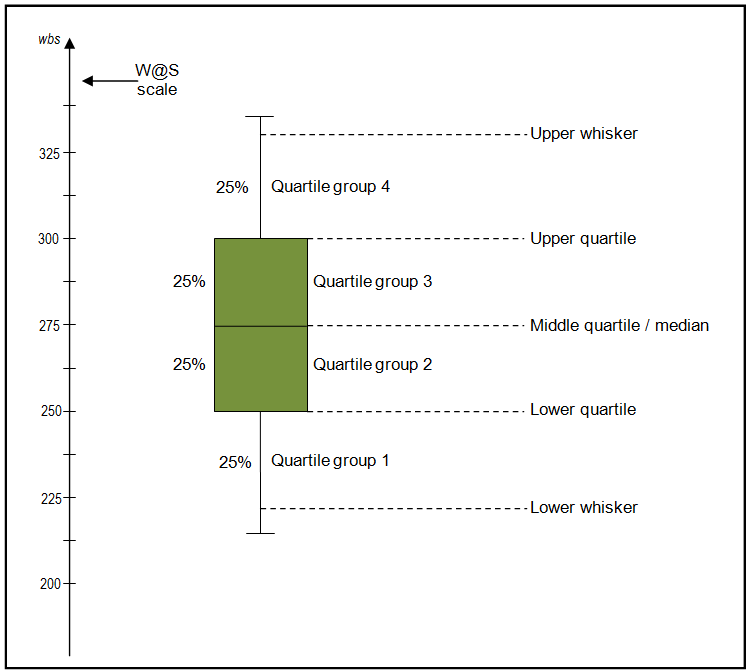

#### Grade point average

###### In the following box plot we can observe the grade point average of the students, the minus 7.0, the greater 9.8.

###### The median is 8.4, which we can observe in the highlighted line, the greater number of students is between 8.0 and 8.9.

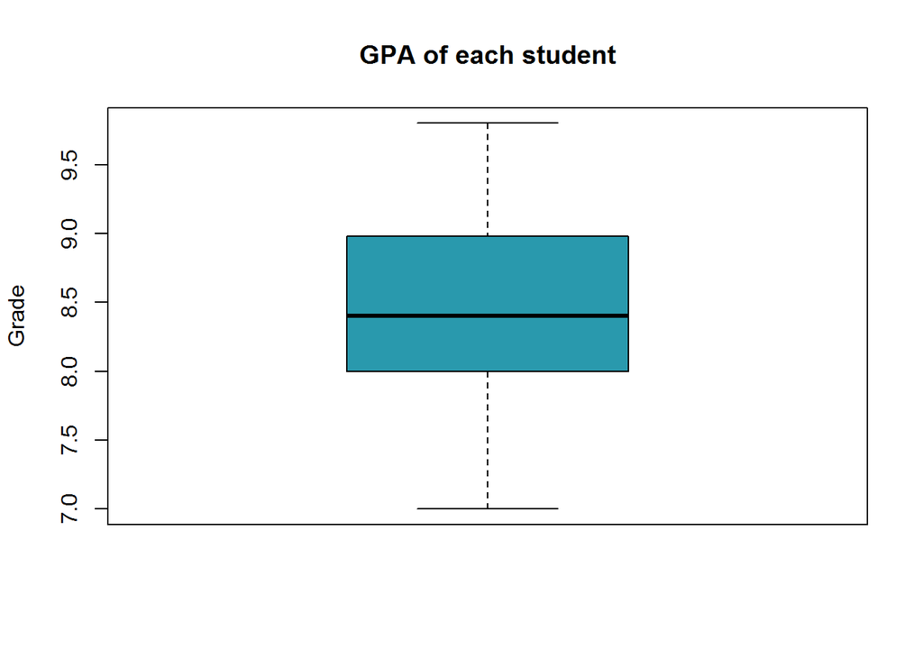

```r
boxplot(dsuaz$promedio, main="GPA of each student", col='#2999AD', ylab="Grade")
```

#### Passion of students for their career

###### Here we observe the passion that the students have for their career.

###### Most students rated their passion for their career between 8 and 10, the median is 9.

###### We have an outlier, that is, isolated data of 4, which means that although there are few concurrences with this data, we have students who answered 4.

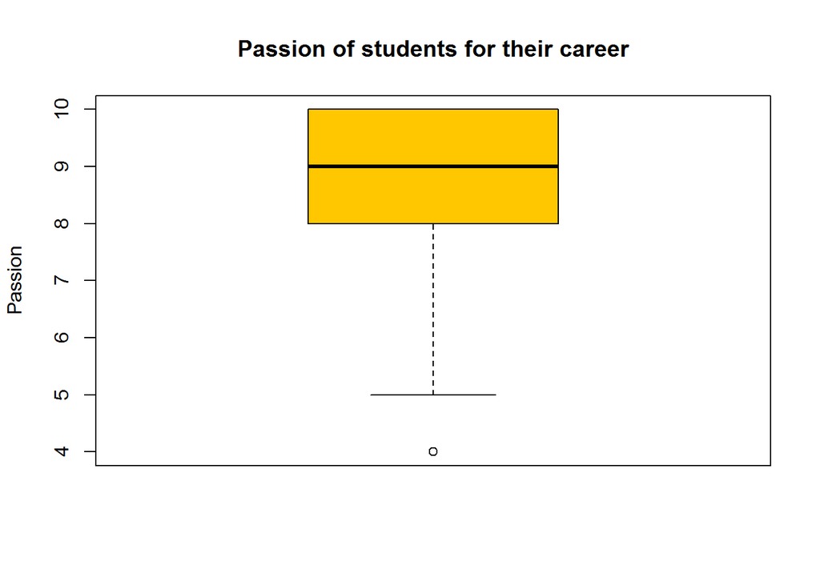

```r
boxplot(dsuaz$pasion_licenciatura, main  = "Passion of students for their career", col = "#FFC700", ylab = "Passion")
```

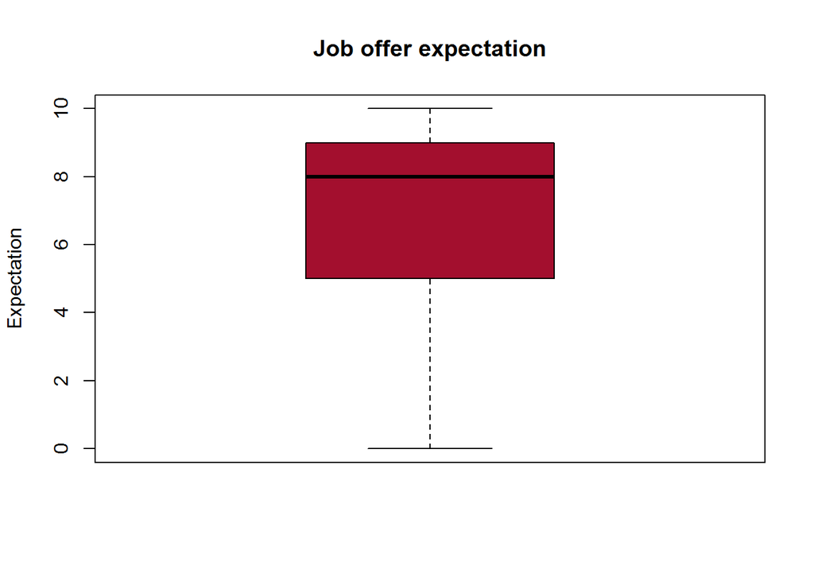

```r
boxplot(dsuaz$oferta_laboral, main="Job offer expectation", col="#A30F2E", ylab="Expectation")
```

#### Students Age

###### Students range from the age of 18 up to 28 years, in the latter case we have an isolated data, so the maximum is marked in 26 years.

###### The median age among respondents is 21 years.

###### Most of the students interviewed are between the ages of 19 and 22 years old.

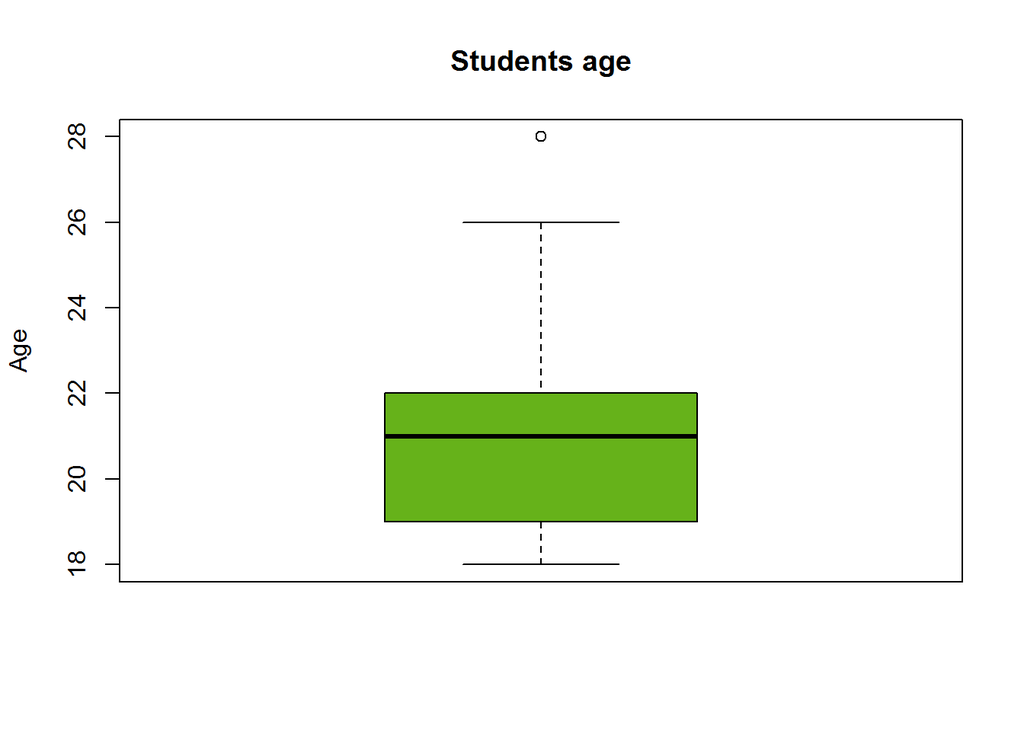

```r
boxplot(dsuaz$edad, main="Students age", col = "#66B21A", ylab="Age")
```

### Gender boxplots

#### Hours of Study according to the gender

###### In the box below we can see the difference in study hours according to the gender of the students.

###### We can observe that the median in both genders is 4 hours of study per day, but in addition there are no minimum, maximum or the other elements of the box plot.

###### This is because almost all students spend 4 hours per day to study, and we only have some isolated cases in both sexes of those who do not study abolutely anything and some others study 6 or 8 hours daily.

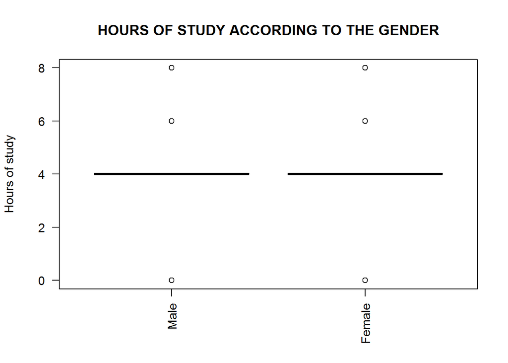

```r
boxplot(split(dsuaz$hrs_estudio_dia,dsuaz$genero),las = 2,main=toupper('Hours of Study according to the gender'), font.main=3, cex.main=1.2, ylab="Hours of study", font.lab=3, col='#FFBD59', names = c('Male','Female'))
```

#### Hours of Sleep according to the gender

###### Here we observe the number of hours of sleep depending on the gender of the students, the median in both genders is 8 hours a day.

###### In both genders the minimum daily sleep time is 3 hours, but only a few women responded that they slept more than 8 hours, so the maximum in the women’s boxplot is 10.

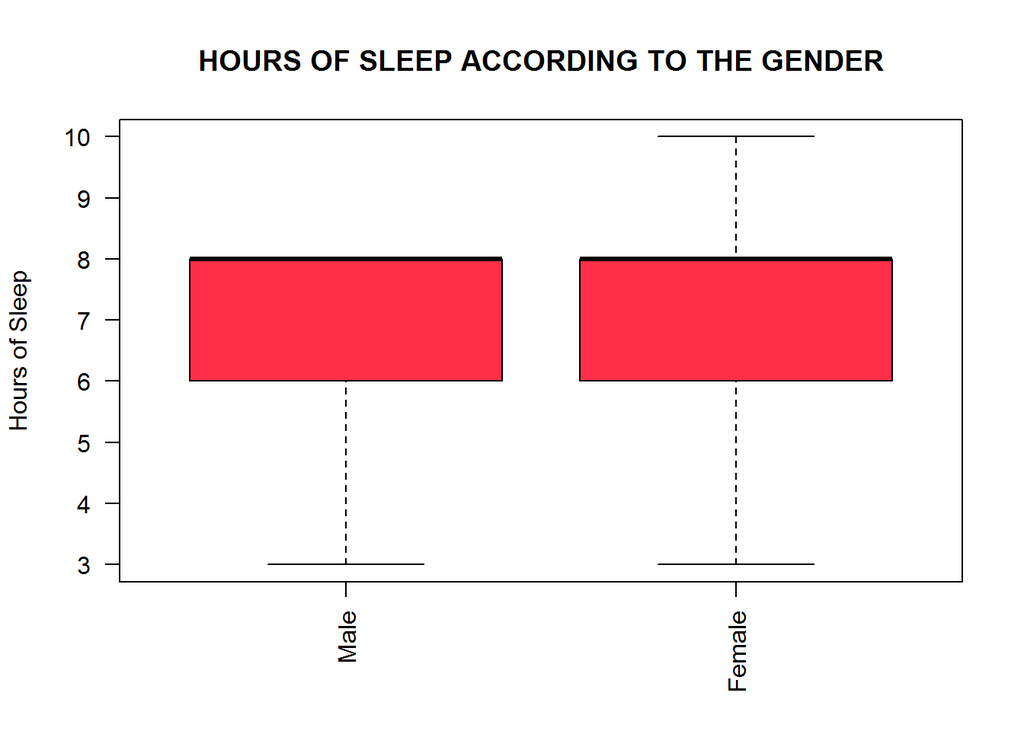

```r
boxplot(split(dsuaz$hrs_dormir_dia,dsuaz$genero),las = 2,main=toupper('Hours of Sleep according to the gender'), font.main=3, cex.main=1.2, ylab="Hours of Sleep", font.lab=3, col='#FF2E47', names = c('Male','Female'))
```

#### Hours of Exercise according to the gender

###### This graph shows the number of hours dedicated to physical exercise by gender.

###### In both genders the median and the first quartile are in the same place, 0, which indicates that most students do not spend time exercising daily.

###### However in the graph of the masculine gender we can observe the maximum and the third quartile in 4 as opposed to the graph of the feminine gender that its third quartile is in 2 and the maximum in 4, this means that of Students who do exercise men spend more time than women exercising.

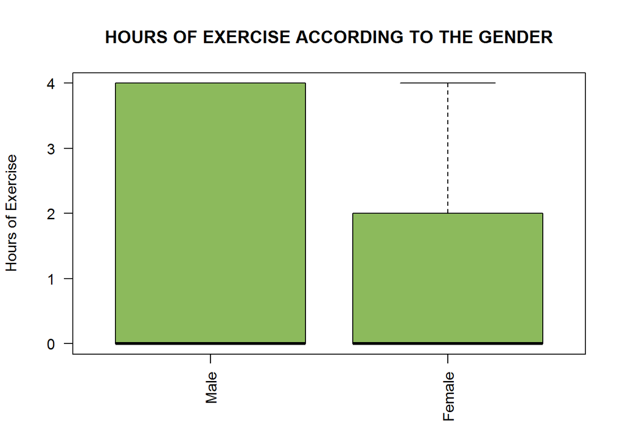

```r
boxplot(split(dsuaz$hrs_ejercicio_dia,dsuaz$genero),las = 2,main=toupper('Hours of Exercise according to the gender'), font.main=3, cex.main=1.2, ylab="Hours of Exercise", font.lab=3, col='#8CBA5C', names = c('Male','Female'))
```

#### Hours of Video Games according to the gender

###### In the following graph we can observe the amount of hours that students dedicate to playing video games according to the masculine or feminine gender.

###### On the left side we can see the box plot of the masculine gender, the median is 2, the first and third quartiles are between 0 and 4, which indicates that most male students dedicated between 0 or 4 hours playing video games daily, the maximum is at 6.

###### On the opposite side, there are the results of the female students, who agreed not to spend any time of the day playing video games except some who said they dedicate 4 or 6 hours a day daily.

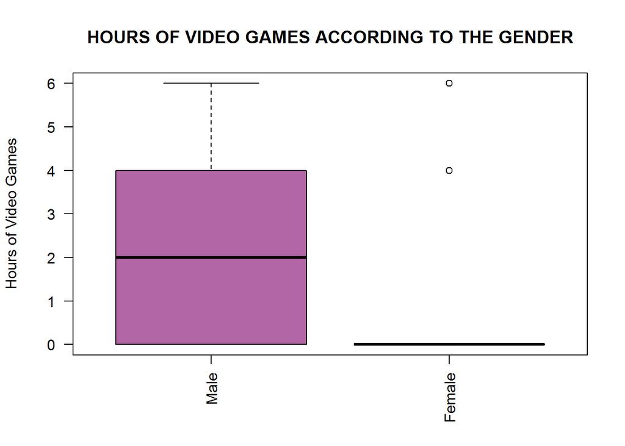

```r
boxplot(split(dsuaz$hrs_vjuegos_dia,dsuaz$genero),las = 2,main=toupper('Hours of Video Games according to the gender'), font.main=3, cex.main=1.2, ylab="Hours of Video Games", font.lab=3, col='#B266A6', names = c('Male','Female'))
```

#### Hours of TV according to the gender

###### Below we can see the number of hours students spend watching TV per day according to their gender.

###### In both genders agreed on the first and third quartiles, which are between 0 and 4, the same as the minimum and the median found at 0, which indicates that a significant proportion of the students do not dedicate Time to watch television, however the majority is between 0 and 4 hours a day.

###### We can also observe that there are men who spend more time than women in front of the TV, since they go from 4 to 6 hours a day from the third quartile to the maximum value.

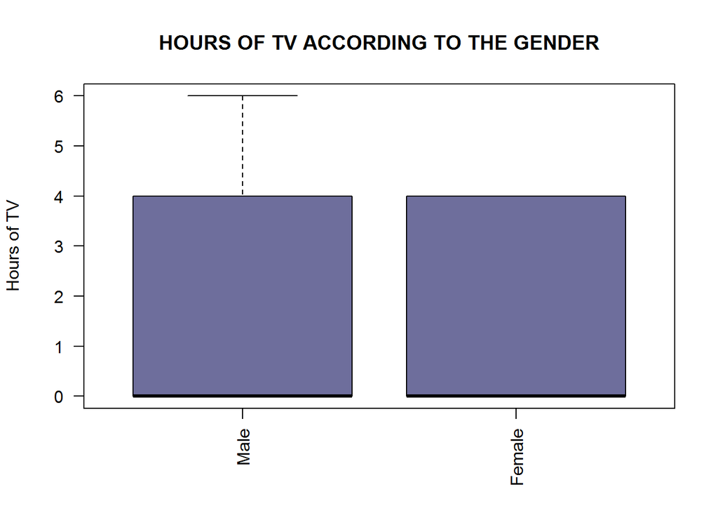

```r
boxplot(split(dsuaz$hrs_tv_dia,dsuaz$genero),las = 2,main=toupper('Hours of TV according to the gender'), font.main=3, cex.main=1.2, ylab="Hours of TV", font.lab=3, col='#6E6E9C', names = c('Male','Female'))
```

#### Hours of Social Activity according to the gender

###### Below we can see the number of hours dedicated to social activities per day.

###### Here we can see that both genders seem more than one could imagine, since both graphs are almost identical, except for the isolated cases that appear.

###### Both men and women spend between 0 and 6 hours for social activities daily, in both genders the majority of students spend between 1 and 3 hours a day for these activities.

###### We can also observe that in both genders the median is 2 hours.

###### In both cases we can observe some isolated cases, ranging from 8 to 10 hours for social activities per day.

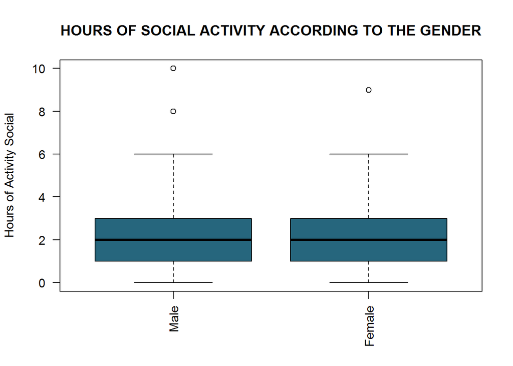

```r
boxplot(split(dsuaz$hrs_actsocial_dia,dsuaz$genero),las = 2,main=toupper('Hours of Social Activity according to the gender'), font.main=3, cex.main=1.2, ylab="Hours of Activity Social", font.lab=3, col='#26667D', names = c('Male','Female'))
```

### Sleepy hours boxplots

#### Sleep hours for each student

###### Here we observe the number of hours of sleep that the students dedicated daily, the answers were of 3 to 10 hours daily.

###### But most students sleep 6-8 hours per day.

###### The median is 8 hours per day, which is recommended by science.

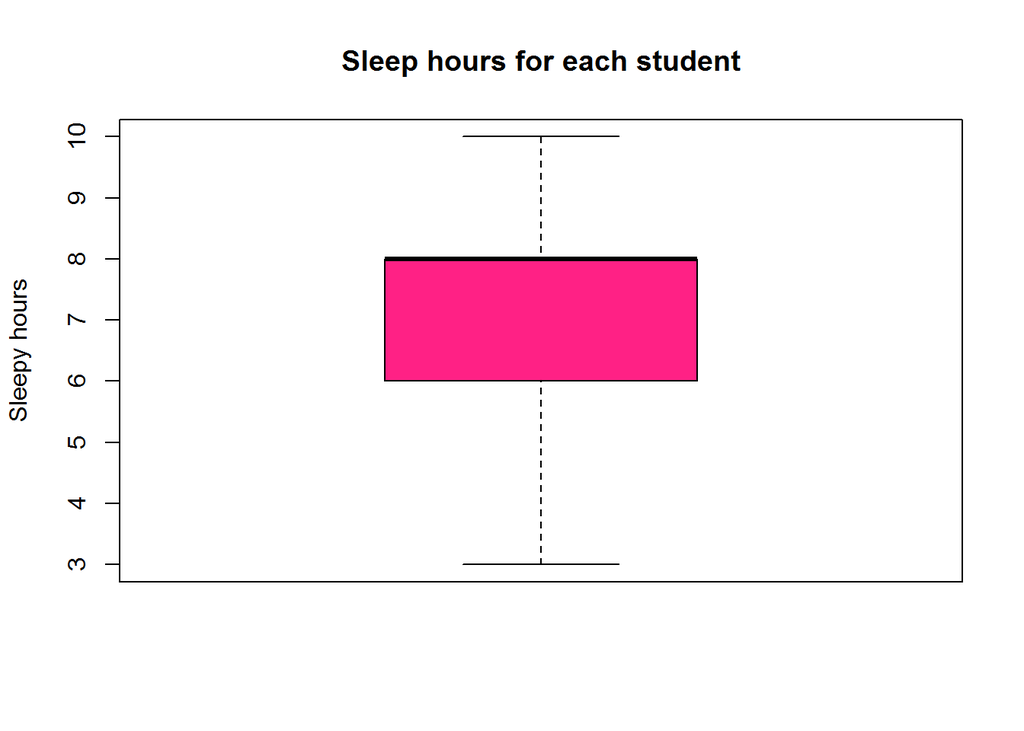

```r
boxplot(dsuaz$hrs_dormir_dia, main="Sleep hours for each student", ylab = "Sleepy hours", col = "#FF2185")
```

#### Hours of sleep according to age

###### In the following graph we can see the number of hours that students sleep depending on the age they have.

###### Most students between the ages of 18, 19, 20, 21, 23 and 24 years old sleep between 6 and 8 hours a day.

###### 22- and 25-year-olds agreed to sleep 8 hours per day, except for some 22-year-olds who reported sleeping 6 or 3 hours per day.

###### On the other hand the students of 26 years said to sleep 10 hrs daily and the students of 28 years 6 hours daily.

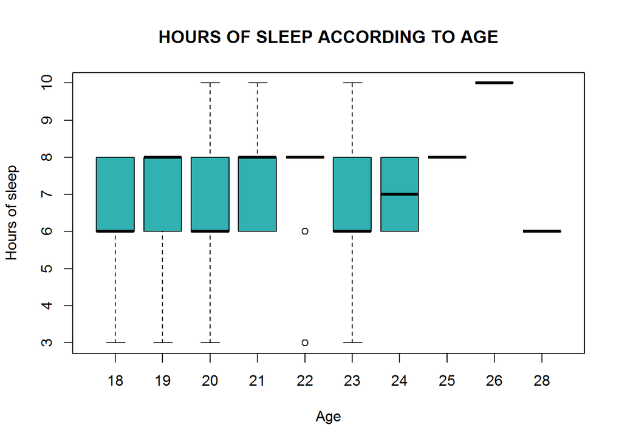

```r
boxplot(split(dsuaz$hrs_dormir_dia,dsuaz$edad),main=toupper('Hours of sleep according to age'), font.main=3, cex.main=1.2, xlab="Age", ylab="Hours of sleep", font.lab=3, col="#31B1B1")
```

#### Hours of Sleep according to the career

###### In the following box plots we can observe the number of hours that students sleep depending on the career they attend.

###### The results are divided into two identical patterns.

###### On the one hand we have Software Engineering students and Psychology students who agreed to sleep 8 hours a day, but also present the same isolated cases in which some students responded to sleep 3, 6 or 10 Hours daily.

###### The other pattern we found with the students of Medicine and those of Chemical Pharmaceutical Biologist, who agreed on their minimum and maximum values between 3 and 8 hours of sleep per day.

###### In addition the median of medical students and QFB is 6 hours. And most of the students in these two careers sleep between 6 and 8 hours a day.

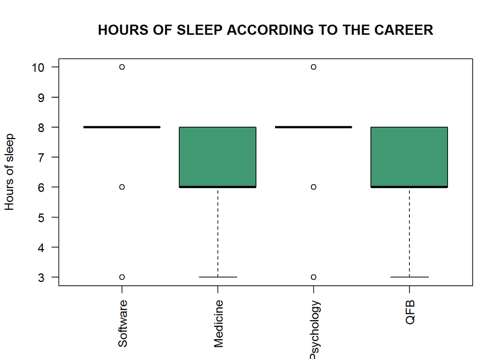

```r
boxplot(split(dsuaz$hrs_dormir_dia,dsuaz$licenciatura),las = 2,main=toupper('Hours of Sleep according to the career'), font.main=3, cex.main=1.2, ylab="Hours of sleep", font.lab=3, col='#409973', names = c('Software','Medicine','Psychology','QFB'))
```

### Study hours boxplots

#### Study hours each day

###### In the box below we can observe the number of hours students interviewed dedicated to studying during the day.

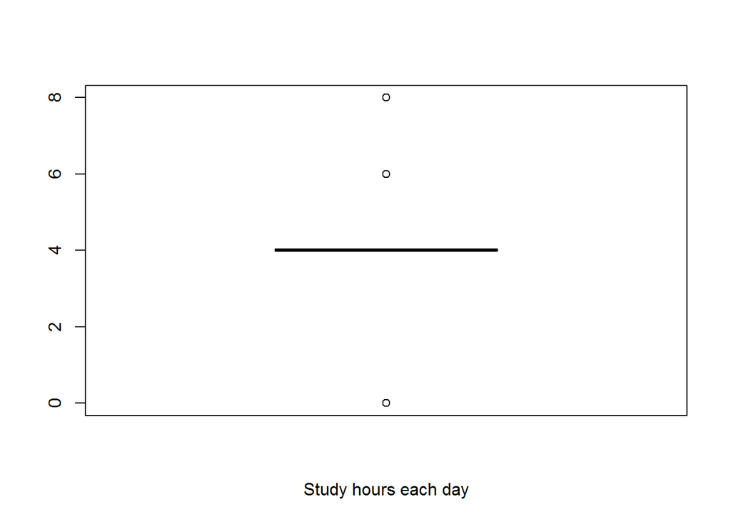

```r
boxplot(dsuaz$hrs_estudio_dia, xlab="Study hours each day")
```

#### Hours of Study according to age

##### Below we can see the number of hours students study per day, thanks to this graph we can realize that most students study the same number of hours regardless of the age they have.

###### We might think that the younger the student is less dedicated or spend less time studying, but thanks to this survey we were able to realize that age does not have a strong impact on the amount of hours that the students invest in their preparation outside the classroom.

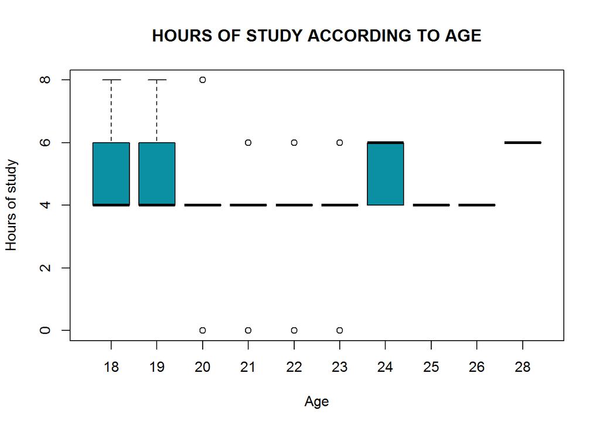

```r
boxplot(split(dsuaz$hrs_estudio_dia,dsuaz$edad),main=toupper('Hours of Study according to age'), font.main=3, cex.main=1.2, xlab="Age", ylab="Hours of study", font.lab=3, col="#0A8FA3")
```

#### Hours of Study according to the semester

###### In the next block we look at the number of hours that students spend studying outside the classroom depending on the semester they attend.

###### Most students agree to study 4 hours per day after school, nevertheless we have some isolated data from students who do not spend any time to study per day.

###### Something important to note in this graph is that no matter what level they are in during their career, students usually spend the same amount of time in their preparation outside the classroom.

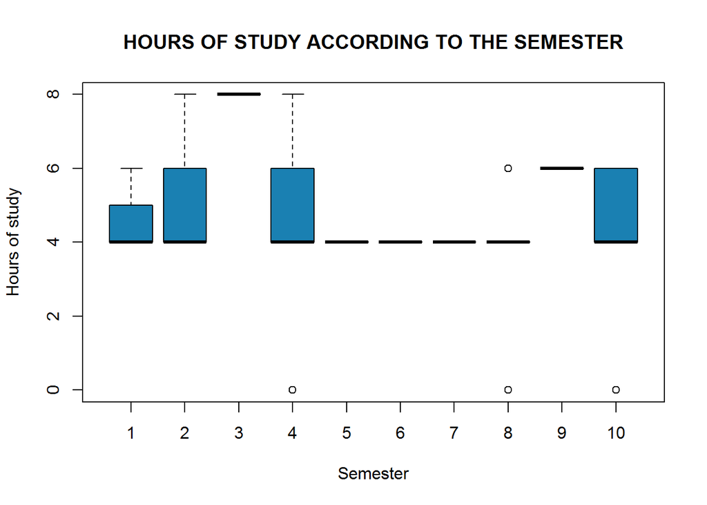

```r
boxplot(split(dsuaz$hrs_estudio_dia,dsuaz$semestre),main=toupper('Hours of Study according to the semester'), font.main=3, cex.main=1.2, xlab="Semester", ylab="Hours of study", font.lab=3, col="#1A80B2")
```

#### Hours of Study according to the career

###### This chart shows the number of hours that students spend studying outside the classroom based on the degree they are studying.

###### We can see that Software Engineering, Psychology and QFB have the same result, which means that students in these degrees study 4 hours per day while not in class. As we observed in the graph above, they present outliers of students who study 6 hours a day or who do not dedicate time to study at all.

###### In the case of medicine our median is at the same level as the other careers, 4, but here we have a greater range of answers, since the third quartile is in 6 hours per day and also a maximum value of 8 hours.

###### This means that most medical students invest between 4 and 6 hours per day studying at home, but there are also medical students who study up to 8 hours a day.

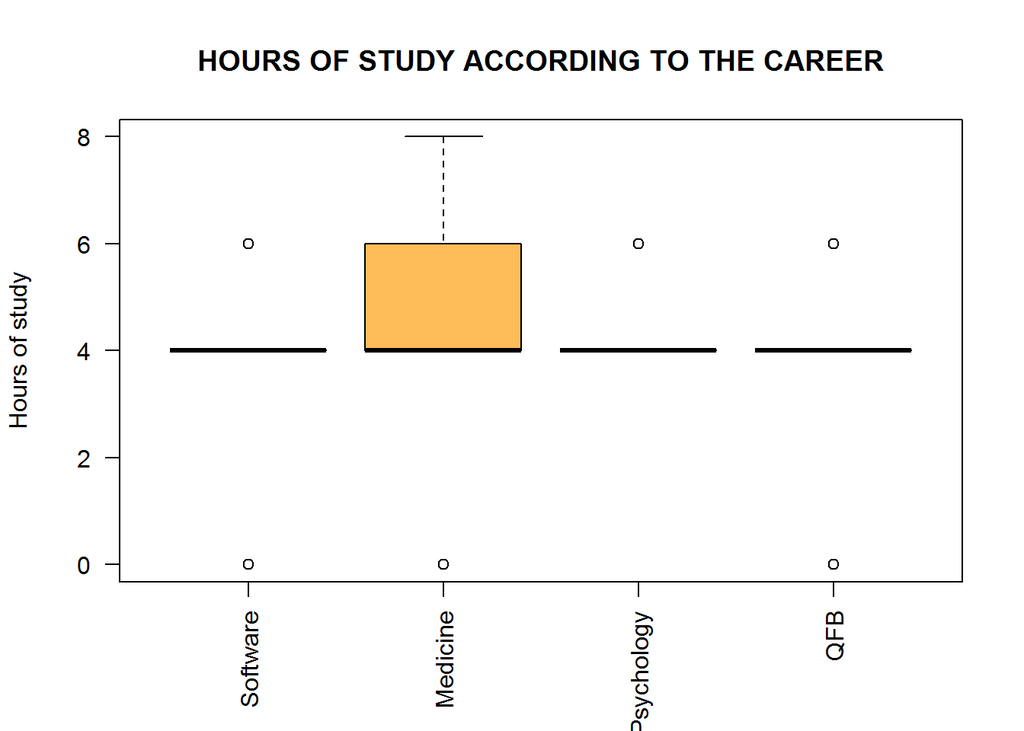

```r
boxplot(split(dsuaz$hrs_estudio_dia,dsuaz$licenciatura),las = 2,main=toupper('Hours of Study according to the career'), font.main=3, cex.main=1.2, ylab="Hours of study", font.lab=3, col='#FFBD59', names = c('Software','Medicine','Psychology','QFB'))
```

### Career boxplots

#### Hours at university according to the career

###### According to the following graph we can observe that the amount of hours that the students spend in the university receiving classes is somewhat variable depending to the career that they are studying.

###### In Software Engineering most students spend in the classroom between 4 and 7 hours a day, the median is 6 hours. But the minimum value that they answered is 0, to which we assume that they are students who are doing their thesis project and they have already accredited the total of necessary subjects to be titled.

###### In the case of Medicine almost every student responded that they spent 7 hours a day in the university, except for some isolated cases that said to spend only 6 hours.

###### In the psychology course, the students agreed to spend 6 hours studying in the university daily, but there are also isolated cases of those who spend 7 hours.

###### Finally, in the case of QFB students range from 4 hours to 8 hours a day in college. Although the majority spend between 6 and 8 hours a day, the median of QFB students is 7 hours.

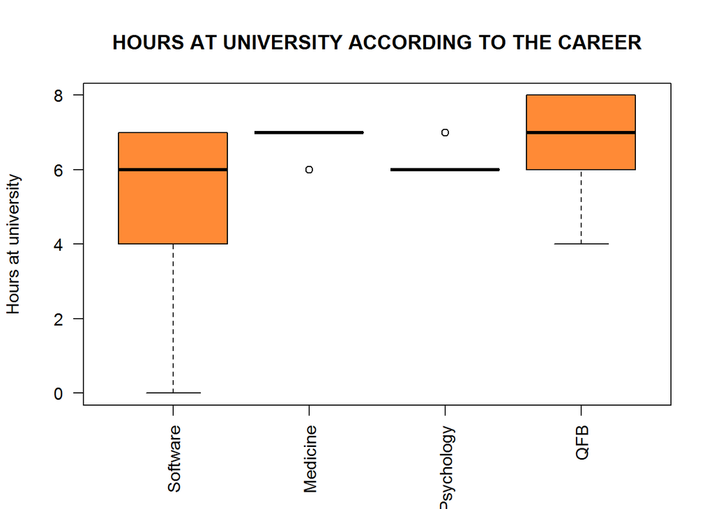

```r
boxplot(split(dsuaz$hrs_universidad_dia,dsuaz$licenciatura),las = 2,main=toupper('Hours at University according to the career'), font.main=3, cex.main=1.2, ylab="Hours at university", font.lab=3, col='#FF8A36', names = c('Software','Medicine','Psychology','QFB'))
```

#### Difficulty appreciated according to the career

###### The graph below shows the level of difficulty students perceive in their careers.

###### The values are as follows:

###### 1 = Easy

###### 2 = Regular

###### 3 = Difficult

###### 4 = Vey Difficult

###### In the case of software engineering, 100 percent of students are in the range of 2 to 3, that is, between regular and difficult, the median is regular.

###### On the other hand, almost every medical student thinks that his career is difficult, except for some students who qualified the difficulty in the other levels.

###### In case of psychology also almost every student responded that his career is regular, although we also have isolated cases that qualify the career as easy or difficult.

###### Finally in QFB, most students think that the course is regular or rifficult, but we also have students who think it is very difficult.

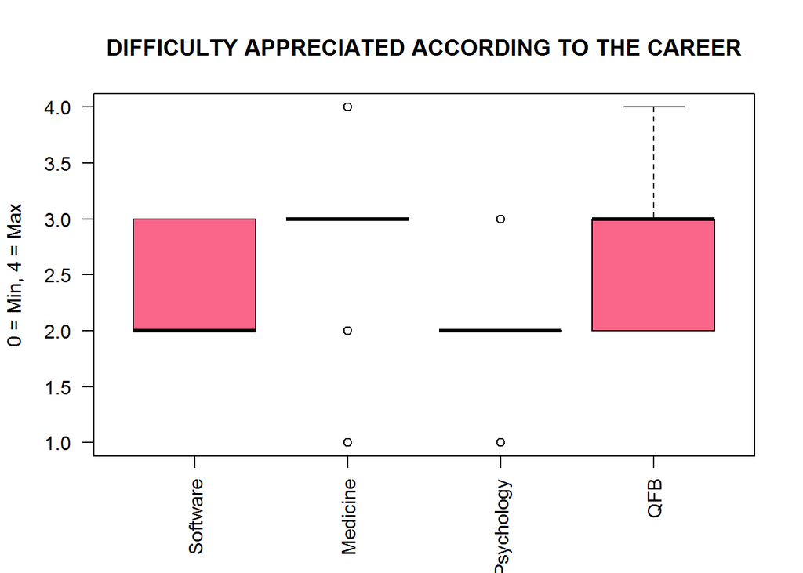

```r
boxplot(split(dsuaz$dificultad_licenciatura,dsuaz$licenciatura),las = 2,main=toupper('Difficulty appreciated according to the career'), font.main=3, cex.main=1.2, ylab="0 = Min, 4 = Max", font.lab=3, col='#FA668A', names = c('Software','Medicine','Psychology','QFB'))
```

#### Repeated subjects according to the career

###### According to the data we collect, students of Software Engineering are those who tend to repeat at least one subject. In the other careers, almost every student responded that they did not repeat any subject yet.

###### However, in the four careers studied we find some isolated cases of students who have repeated one or more subjects.

###### Just as in Software Engineering is the largest number of students with repeated subjects, the career with fewer students with repeated subjects is Psychology.

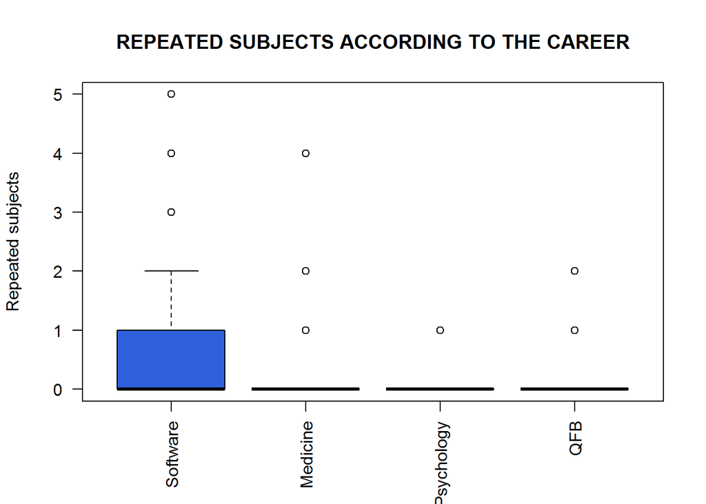

```r
boxplot(split(dsuaz$materias_repetidas,dsuaz$licenciatura),las = 2,main=toupper('Repeated subjects according to the career'), font.main=3, cex.main=1.2, ylab="Repeated subjects", font.lab=3, col='#2E61DB', names = c('Software','Medicine','Psychology','QFB'))
```

#### Passion according to the career

###### Most students regardless of the career they are studying measure their passion for the career between 8 and 10 on a scale of 0 to 10.

###### 50 percent of software engineering students said they felt between 8 and 9 of passion for their career.

###### In the case of medicine we obtained the lowest significant level in terms of passion for the career, which is 5, but we also have an outlier with a value of 4, same case in QFB.

###### The students with the greatest passion for their career are those who are studying Psychology, since more than 50 percent of the students said to have between 9 and 10 of passion for their career.

###### In QFB the majority of students are between 8 and 10 of passion for their career and the lowest value is 6.

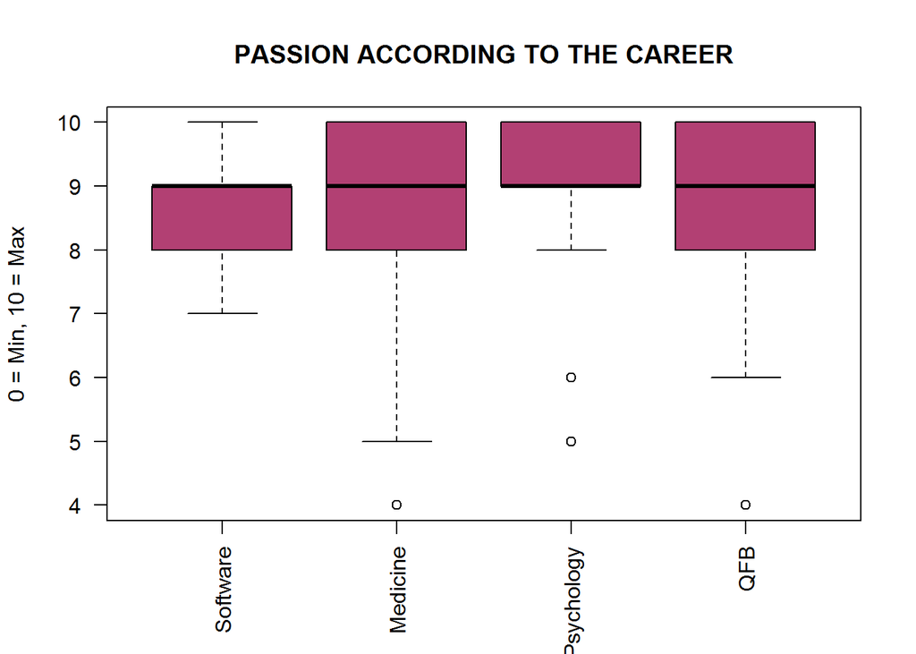

```r
boxplot(split(dsuaz$pasion_licenciatura,dsuaz$licenciatura),las = 2,main=toupper('Passion according to the career'), font.main=3, cex.main=1.2, ylab="0 = Min, 10 = Max", font.lab=3, col='#B24073', names = c('Software','Medicine','Psychology','QFB'))
```

#### Semester according to the career

###### The students interviewed currently attend from the first to the tenth semester, here we can observe in the colored area in which semester with the largest number of students depending on the career they study.

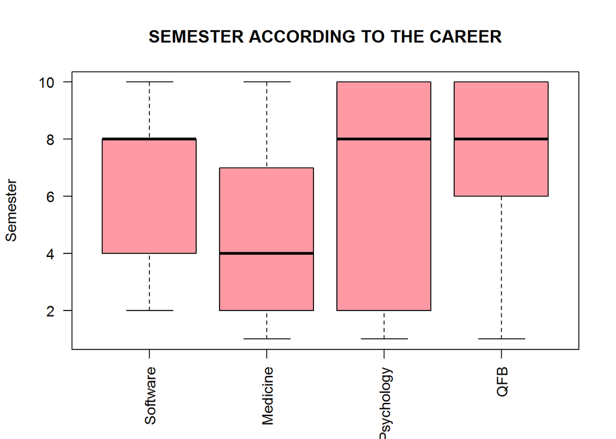

```r
boxplot(split(dsuaz$semestre,dsuaz$licenciatura),las = 2,main=toupper('Semester according to the career'), font.main=3, cex.main=1.2, ylab="Semester", font.lab=3, col='#FF99A3', names = c('Software','Medicine','Psychology','QFB'))
```

#### Grade point average according to the career

###### Students who have the most variation in their academic averages are those who belong to Software engineering, in this career we also have the lowest and highest gpa of the total of students interviewed.

###### The highest average is 9.8 and the lowest is 7.0.

###### Medical students have the lowest gpa range compared the other courses. Fifty percent of medical students have an average of 8.0 to 8.5, 25 percent have an gpa of less than 8.0 and the other 25 percent have gpas of between 8.5 and 9.1.

###### Psychology students have the best gpas, with 50 percent of students having averages of 8.3 and 9.1.

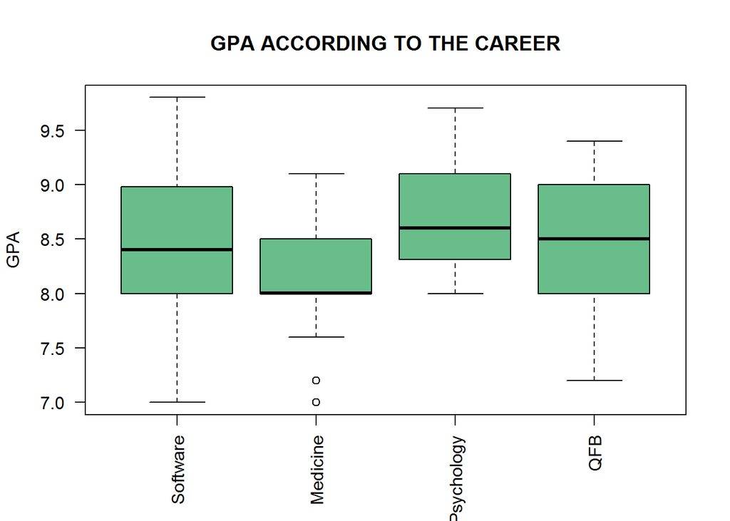

```r
boxplot(split(dsuaz$promedio,dsuaz$licenciatura),las = 2,main=toupper('GPA according to the career'), font.main=3, cex.main=1.2, ylab="GPA", font.lab=3, col='#69BD8A', names = c('Software','Medicine','Psychology','QFB'))
```

[figure not shown]

```r
boxplot(split(dsuaz$semestre,dsuaz$licenciatura),las = 2,main=toupper('Job offer expectation according to the career'), font.main=3, cex.main=1.2, ylab="0 = Min, 10 = Max", font.lab=3, col='#992966', names = c('Software','Medicine','Psychology','QFB'))
```

[figure not shown]

```r
boxplot(split(dsuaz$semestre,dsuaz$licenciatura),las = 2,main=toupper('Hours of work expected according to the career'), font.main=3, cex.main=1.2, ylab="Hours of work expected", font.lab=3, col='#1F8594', names = c('Software','Medicine','Psychology','QFB'))
```

## Histograms interpretation

#### Histogram of hours of study per day

###### In this histogram, almost 72% of the students study 2 to 4 hours every day

###### Skewness equals -0.428, which means that the distribution of the data is approximately symmetric. In addition we can observe that the values of mean and mode are 4.248 and 4.

```r
summary(dsuaz$hrs_estudio_dia)
```

```
##    Min. 1st Qu.  Median    Mean 3rd Qu.    Max.
##   0.000   4.000   4.000   4.248   4.000   8.000
```

```r
library(e1071)
skewness(dsuaz$hrs_estudio_dia)
```

```
## [1] -0.428141
```

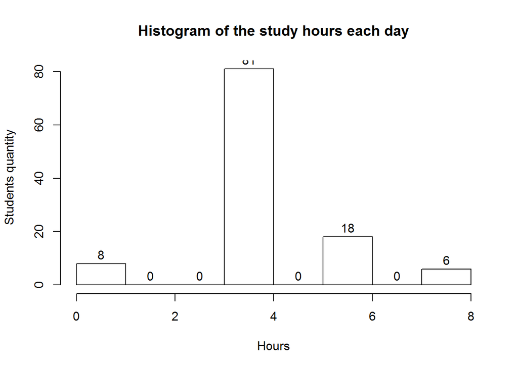

```r
hist(dsuaz$hrs_estudio_dia,
     main = "Histogram of the study hours each day",
     xlab = "Hours",
     ylab = "Students quantity",
     labels = TRUE)
```

#### Histogram of grade point average

###### In this histogram, we can see that the 75% of the students have a qualification between 7.5 and 9.0.

###### In the following case, we have a skewness value of -0.0344, which means that student academic averages are approximately symmetric.

```r
summary(dsuaz$promedio)
```

```
##    Min. 1st Qu.  Median    Mean 3rd Qu.    Max.
##   7.000   8.000   8.400   8.423   8.980   9.800
```

```r
library(e1071)
skewness(dsuaz$promedio)
```

```
## [1] -0.03446313
```

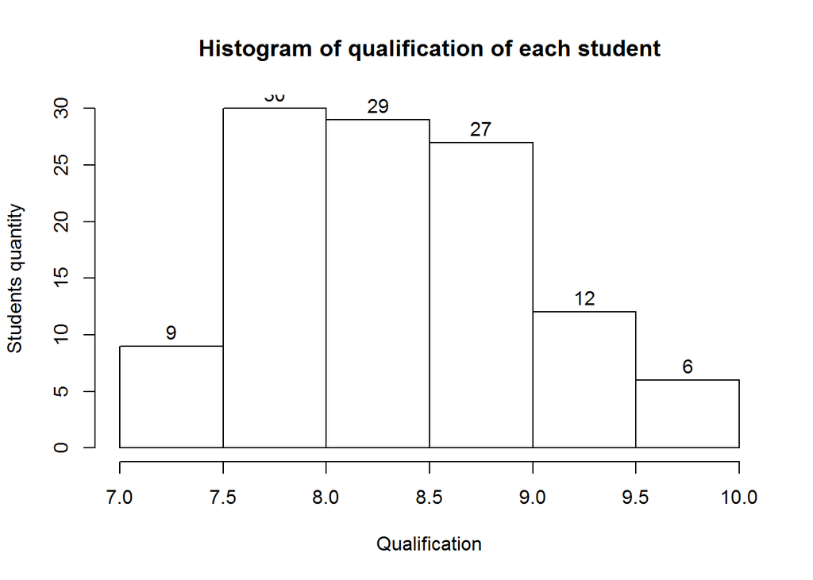

```r
hist(dsuaz$promedio,
     main = "Histogram of qualification of each student",
     xlab = "Qualification",
     ylab = "Students quantity",
     labels = TRUE)
```

#### Histogram of hours of sleep per day

###### In this histogram, we can see that almost 90% of the students sleep between 4 to 8 hours every day.

###### From the value of skewness -0.890, we can say that the distribution of the number of hours that students sleep daily is moderately skewed.

###### Now if we draw the distribution’s shape we can see that the data is moderately skewed left, because the left tail is longer and the most of the distribution is at the right.

```r
summary(dsuaz$hrs_dormir_dia)
```

```
##    Min. 1st Qu.  Median    Mean 3rd Qu.    Max.
##   3.000   6.000   8.000   6.973   8.000  10.000
```

```r
library(e1071)
skewness(dsuaz$hrs_dormir_dia)
```

```
## [1] -0.8900936
```

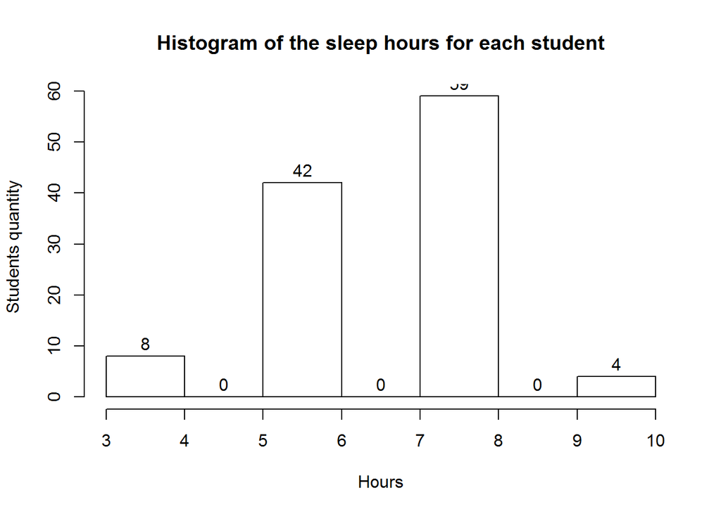

```r
hist(dsuaz$hrs_dormir_dia,
     main = "Histogram of the sleep hours for each student",
     xlab = "Hours",
     ylab = "Students quantity",
     labels = TRUE)
```

#### Histogram on the passion that students have over their career

###### In this histogrm, we can see that over the 65% of the students have a pasion of 9 and 10 for his/her career.

###### The value of skewness is -1.3513, that means that the distribution of data is highly skewed.

###### If we draw the distribution’s shape, we will see that the data is highly skewed left, this can be verified if we look at the results of the summary, there we can realize that the median is greater than the mean, which indicates that in the graph through the distribution’s shape we will first find the mean, then the median and finally the fashion At the highest point.

```r
summary(dsuaz$pasion_licenciatura)
```

```
##    Min. 1st Qu.  Median    Mean 3rd Qu.    Max.
##   4.000   8.000   9.000   8.735  10.000  10.000
```

```r
library(e1071)
skewness(dsuaz$pasion_licenciatura)
```

```
## [1] -1.351363
```

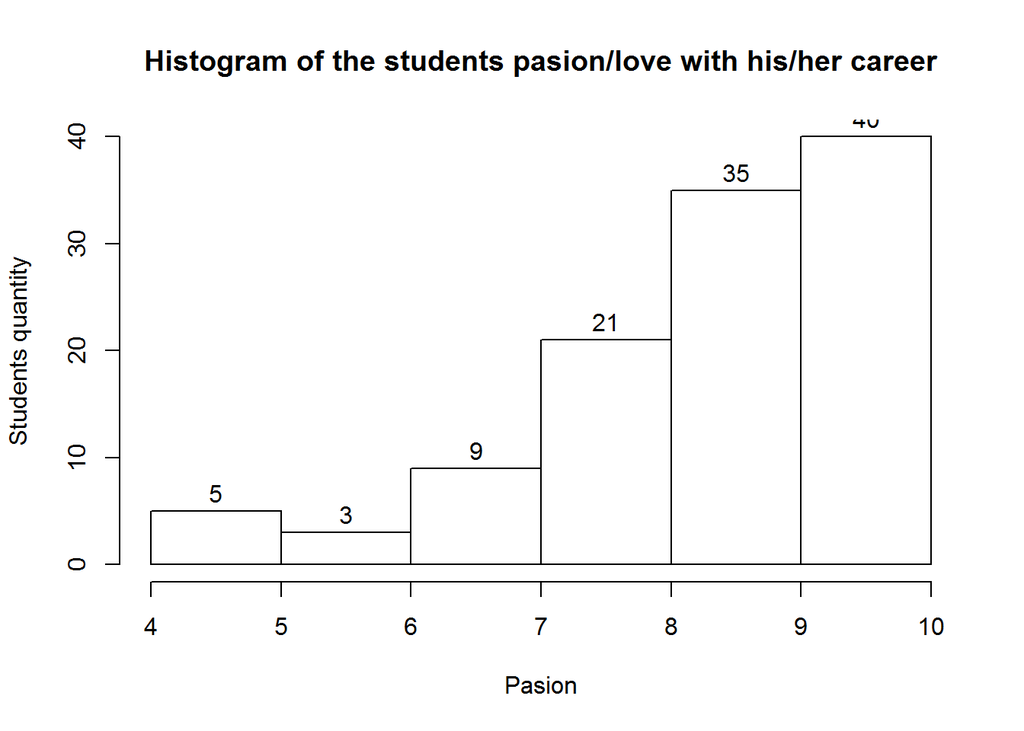

```r
hist(dsuaz$pasion_licenciatura,
     main = "Histogram of the students pasion/love with his/her career",
     xlab = "Pasion",
     ylab = "Students quantity",
     labels = TRUE)
```

#### Histogram on the expectation of job offers

###### In this histogram, the most students have difficulty to get a job of 5, 8 and 10.

###### The value of skewness is -0.7729, which means that the distribution of our data is moderately skewed left.

###### As in the previous data set we can see that the median value is higher than the mean.

```r
summary(dsuaz$oferta_laboral)
```

```
##    Min. 1st Qu.  Median    Mean 3rd Qu.    Max.
##   0.000   5.000   8.000   7.097   9.000  10.000
```

```r
library(e1071)
skewness(dsuaz$oferta_laboral)
```

```
## [1] -0.7729701
```

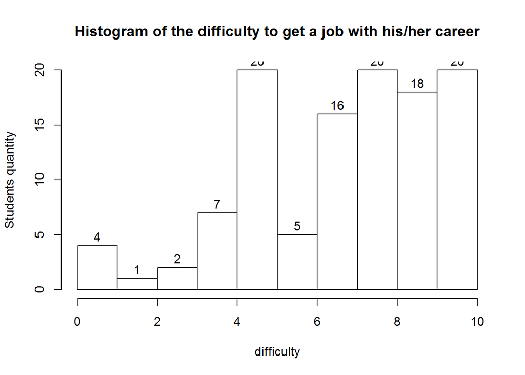

```r
hist(dsuaz$oferta_laboral,
     main = "Histogram of the difficulty to get a job with his/her career",
     xlab = "difficulty",
     ylab = "Students quantity",
     labels = TRUE)
```

#### Histogram on the age of students

###### But if we do the distribution’s shape, we can see that the data is tilted to the left, indicating that we have a skewed right or that they are in a positive direction.

```r
summary(dsuaz$edad)
```

```
##    Min. 1st Qu.  Median    Mean 3rd Qu.    Max.
##   18.00   19.00   21.00   20.99   22.00   28.00
```

```r
library(e1071)
skewness(dsuaz$edad)
```

```
## [1] 0.3920733
```

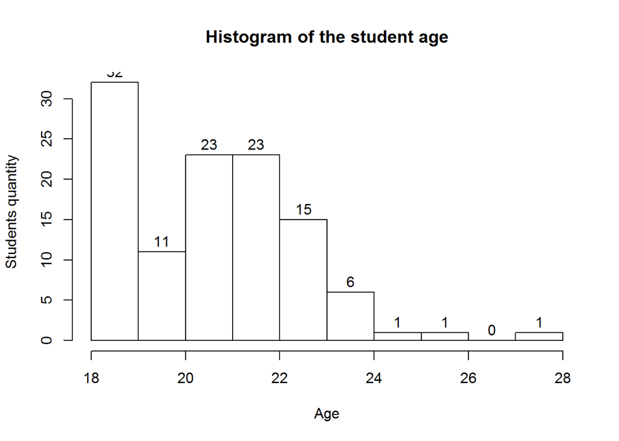

```r
hist(dsuaz$edad,
     main = "Histogram of the student age",
     xlab = "Age",
     ylab = "Students quantity",
     labels = TRUE)
```